# seaborn

Name : Sourabh Dipak Phalatane  
Roll No. B54  
PRN 2425000101  
Exp No 8 : Seaborn

```python
import matplotlib as plt
import seaborn as sns
import pandas as pd
import numpy as np
import plotly.express as px
```

@Categorical Plot

- bar plot
- count plot
- boxplot
- violin plot

```python
tips = sns.load_dataset('tips')
iris = sns.load_dataset('iris')
```

Categoriacal Plots

1. categorical scatter plot
- - stripplot
- - swammplot
2. categorical distribution plot
- - baxplot
- - violinplot
3. categorical estimate plot -> for central tendacy
- - barplot
- - pointplot
- - countplot

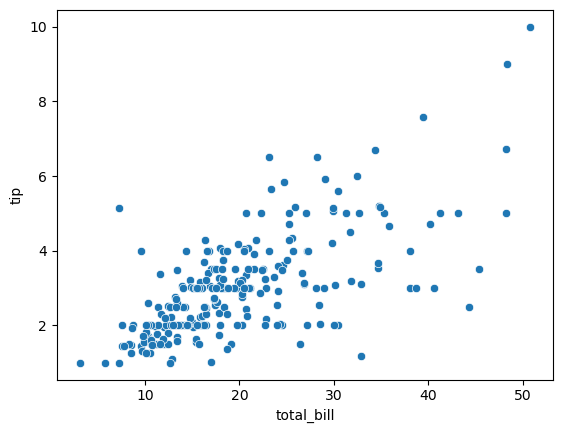

```python
sns.scatterplot(data=tips,x='total_bill',y='tip')
```

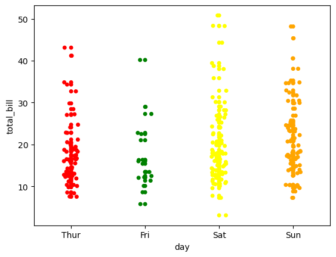

```python
# strip plot  -> axis level function
# ya plot madhe ek categorical data ani dusara numerical data asto
sns.stripplot(data=tips, x='day', y='total_bill',
              hue='day',
              palette=['red','green','yellow','orange'],
              legend=False)

# run one by one

sns.stripplot(data=tips, x='day', y='total_bill',
              hue='day',
              palette=['red','green','yellow','orange'],
              legend=False,
              jitter=False)
```

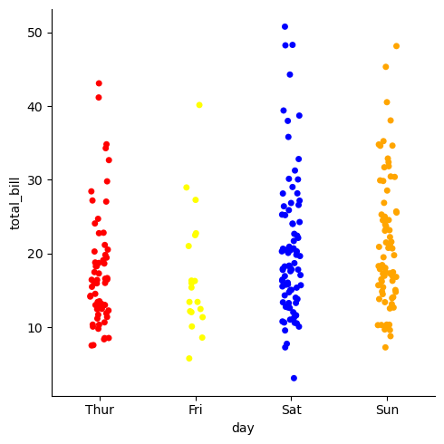

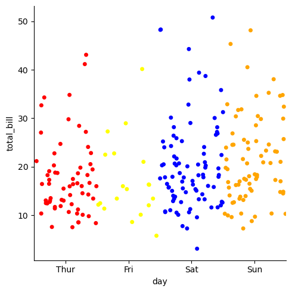

```python
# strip plot -> figure level
# catplot use karanar categorical data represent karnya sathi
# the hue parameter must be a categorical  data

sns.catplot(data=tips,x='day',y='total_bill',kind='strip',
            hue='day',
            palette=['red','yellow','blue','orange'],
            legend=False)

sns.catplot(data=tips,x='day',y='total_bill',kind='strip',
            hue='day',
            palette=['red','yellow','blue','orange'],
            legend=False,
            jitter=0.5
            )
```

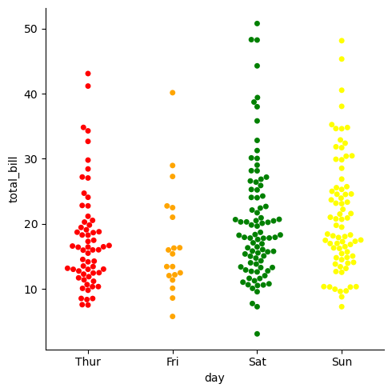

```python
# swamplot
sns.catplot(data=tips,x='day',y='total_bill',kind='swarm',
            hue='day',
            palette=['red','orange','green','yellow'])
```

diif between swarm plot and strip plot

- swarmplot atomatically arange distribution of your data

diff between scatter and distribution plot

- scatter analyze using bivariate info
- distribution plot uses single info

#### Distribution plot

- box plot
- violin plot

##### Box plot

- in short based on quartiles
- A boxplot is a standard way of displaying the distribution of data based on a five number summary ("minimum",first quartile[Q1], median,third quartile[Q3],"maximum")
- it can tell you about outliers and what their values are. Boxplot can also tell you if your date is symmetrical how tightly your data is grouped and if and how your data is skewed
- minimum = [Q1] - 1.5*IQR
- maximum = [Q3] + 1.5*IQR

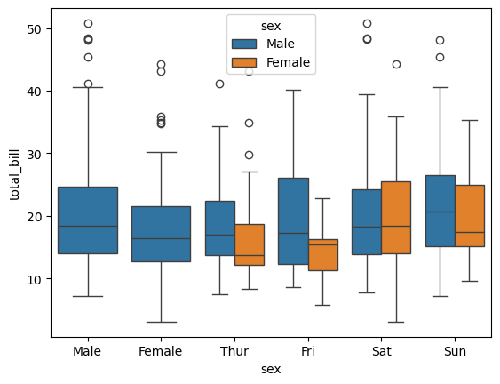

```python
# box plot
sns.boxplot(data=tips,x='sex',y='total_bill')
# sns.boxplot(data=tips,x='day',y='total_bill')
sns.boxplot(data=tips,x='day',y='total_bill',hue='sex')
```

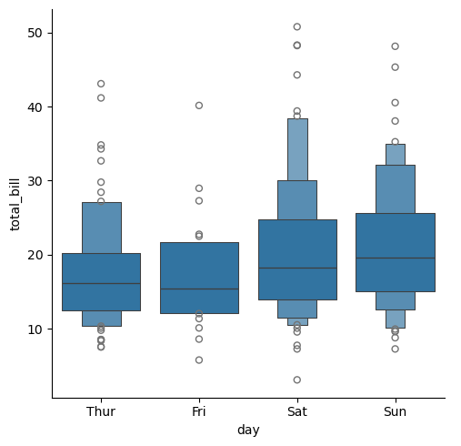

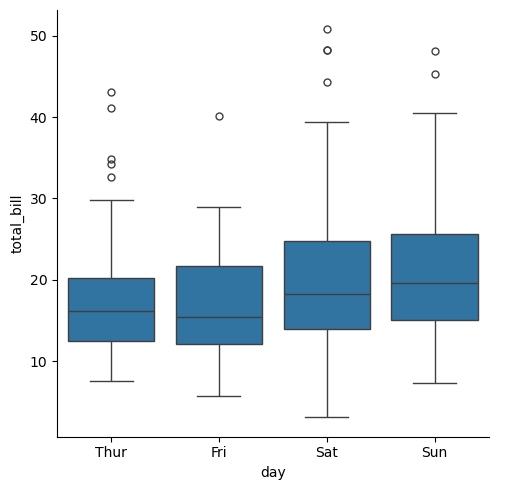

```python
# catplot -> figure level
sns.catplot(data=tips,x='day',y='total_bill',kind='boxen')
sns.catplot(data=tips,x='day',y='total_bill',kind='box')
```

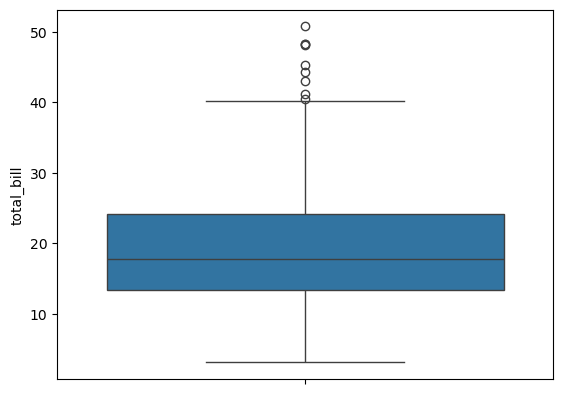

```python
# single boxplot
sns.boxplot(data=tips,y='total_bill')
# one box plot for your entire total_bill column
```

Voilin plot -> (Boxplot + KDEplot)

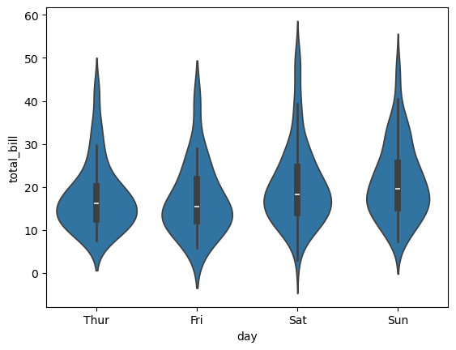

```python
sns.violinplot(data=tips,x='day',y='total_bill')
```

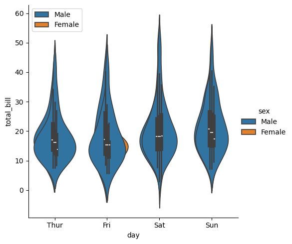

```python
sns.catplot(data=tips,x='day',y='total_bill',kind='violin',hue='sex',split=True)
sns.violinplot(data=tips,x='day',y='total_bill')
```

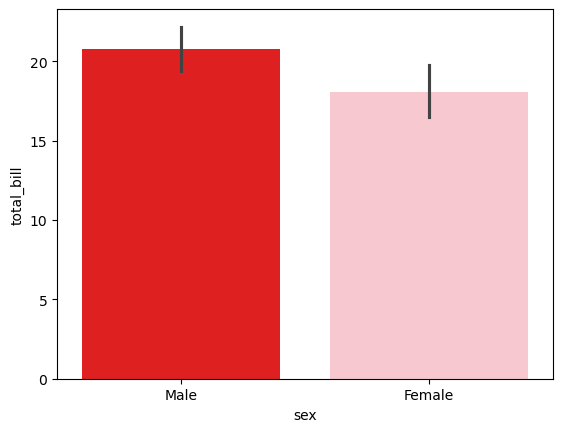

```python
# Barplot
sns.barplot(data=tips,x='sex',y='total_bill',
            hue='sex',palette=['red','pink'])
# here total_bill is the avg of male and female
```

- the black which is present at middle of the column represents, when there are multiple observations in each category, it also uses botstraping to compute a confidnce interval around the estimate, which is plotted using error bars (repete x axis)

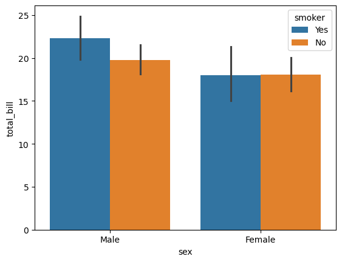

```python
sns.barplot(data=tips,x='sex',y='total_bill',
            hue='smoker')
# to remove that erroe bar the prameter is used errorbar
```

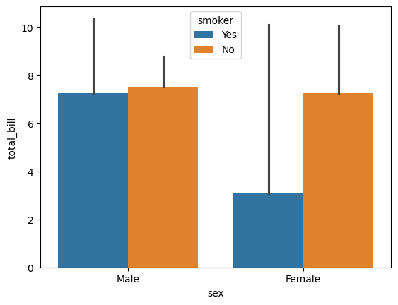

```python
sns.barplot(data=tips,x='sex',y='total_bill',
            hue='smoker',estimator=np.std)

sns.barplot(data=tips,x='sex',y='total_bill',
            hue='smoker',estimator=np.min)
```

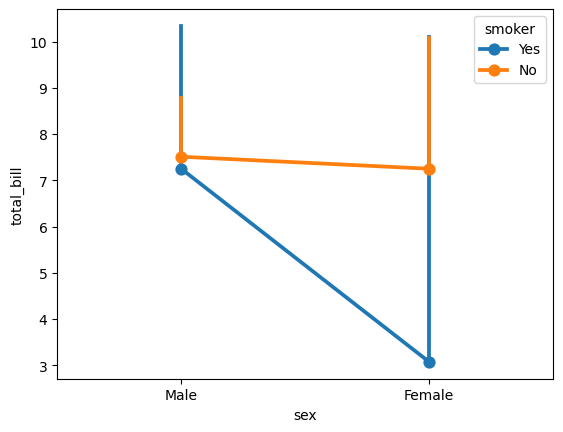

```python
# point plot
# bar ke jagah sirf points hote hai
# it conncts points which is present at peak
# pointplot gives better analysis of categories
sns.pointplot(data=tips,x='sex',y='total_bill',hue='smoker',estimator=np.min)
```

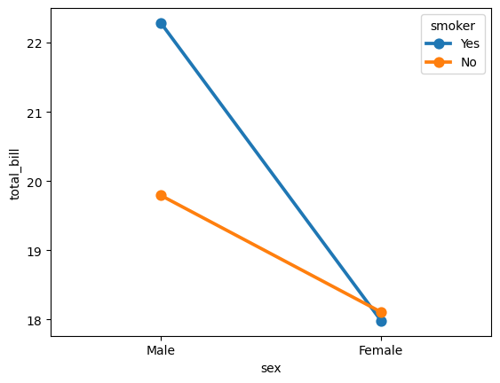

```python
# sns.pointplot(data=tips,x='sex',y='total_bill',hue='smoker')
sns.pointplot(data=tips,x='sex',y='total_bill',hue='smoker',errorbar=None)
```

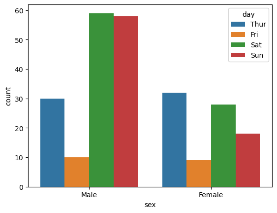

```python
# count plot
# it basicallly function of value count
# it workd on categorical values to find out count
# Histogram used for numerical values where as countplot workd on categorical values
sns.countplot(data=tips,x='sex',hue='day')
```

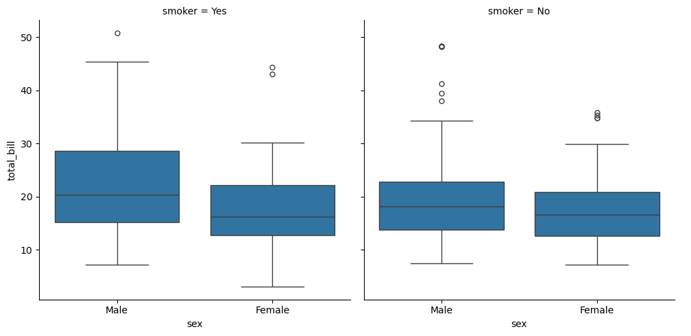

```python
# facet is used
# when we want to analysis side by side then wehave to "col"
sns.catplot(data=tips,x='sex',y='total_bill',col='smoker',kind='box')
```

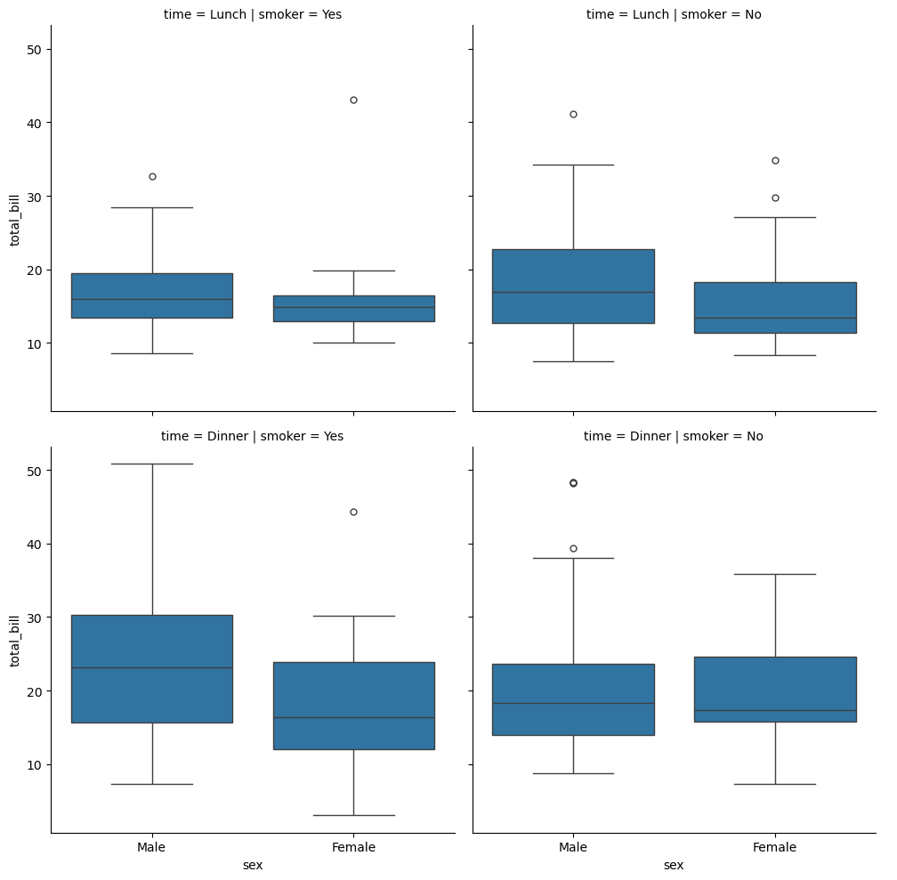

```python
sns.catplot(data=tips,x='sex',y='total_bill',col='smoker',kind='box',row='time')
```

regplot

```python
# regression mhanje to minimize the error it will cal one line which is gone near from through all points
tips
```

|  | total_bill | tip | sex | smoker | day | time | size |
| --- | --- | --- | --- | --- | --- | --- | --- |
| 0 | 16.99 | 1.01 | Female | No | Sun | Dinner | 2 |
| 1 | 10.34 | 1.66 | Male | No | Sun | Dinner | 3 |
| 2 | 21.01 | 3.50 | Male | No | Sun | Dinner | 3 |
| 3 | 23.68 | 3.31 | Male | No | Sun | Dinner | 2 |
| 4 | 24.59 | 3.61 | Female | No | Sun | Dinner | 4 |
| ... | ... | ... | ... | ... | ... | ... | ... |
| 239 | 29.03 | 5.92 | Male | No | Sat | Dinner | 3 |
| 240 | 27.18 | 2.00 | Female | Yes | Sat | Dinner | 2 |
| 241 | 22.67 | 2.00 | Male | Yes | Sat | Dinner | 2 |
| 242 | 17.82 | 1.75 | Male | No | Sat | Dinner | 2 |
| 243 | 18.78 | 3.00 | Female | No | Thur | Dinner | 2 |

244 rows × 7 columns

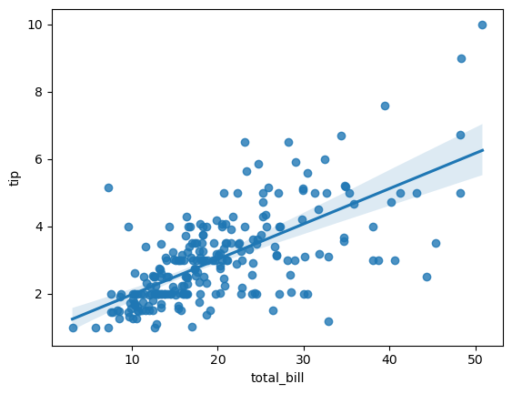

```python
# axis level
sns.regplot(data=tips,x='total_bill',y='tip')
```

In the simplest invocation,both(regplot + lmplot) function draw a scatterplot of two variable, x and y,and then fit th regression model y ~ x and plot the resulting line and a 95% confidence interval for that regression

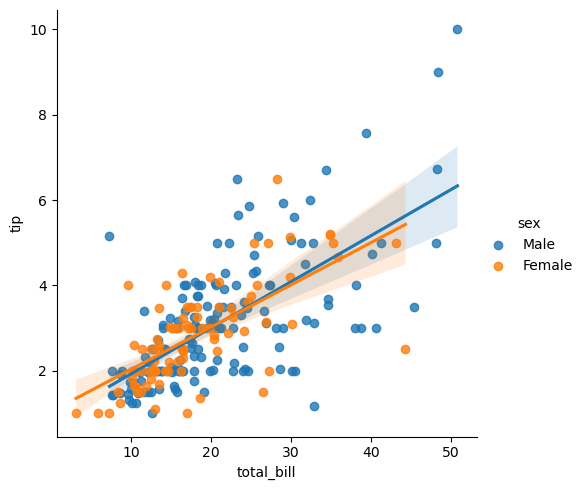

```python
sns.lmplot(data=tips,x='total_bill',y='tip',hue='sex')

# in regplot we cant apply hue parameter
# but in lmplot we can apply hue parameter
```

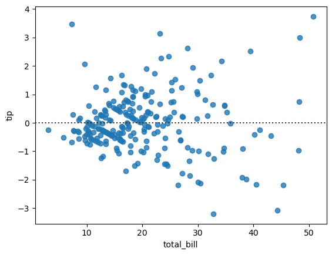

```python
# resideplot
# it us based on regplot
# the dotted line is regression line and it shows distance
# prediction ka error
sns.residplot(data=tips,x='total_bill',y='tip')
```

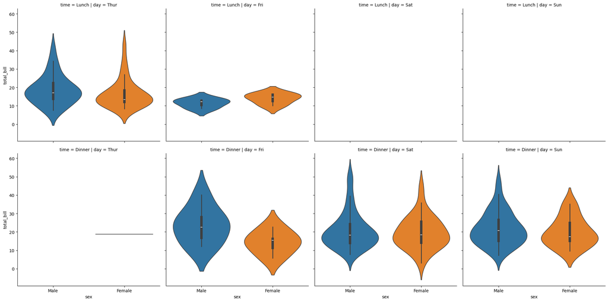

```python
# multi-grid plot
# facet-grid

# figure level -> relplot -> displot -> catplot-> lmplot
# in tino mai facet(row and col) ka option hota hai
sns.catplot(data=tips,x='sex',y='total_bill',kind='violin',hue='sex',col='day',row='time')
```

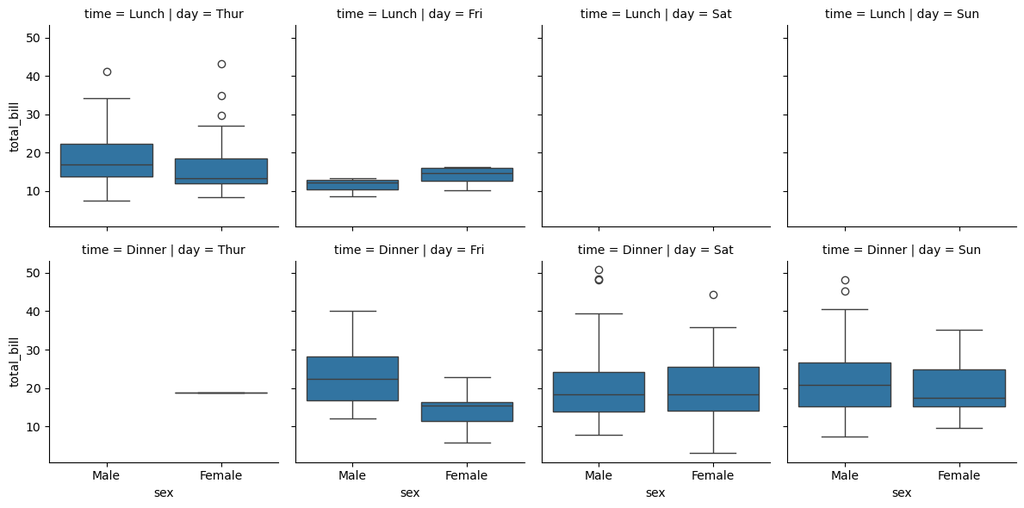

```python
# facetgrid
# more customizes

g =sns.FacetGrid(data=tips,col='day',row='time')
g.map(sns.boxplot,'sex','total_bill' )
```

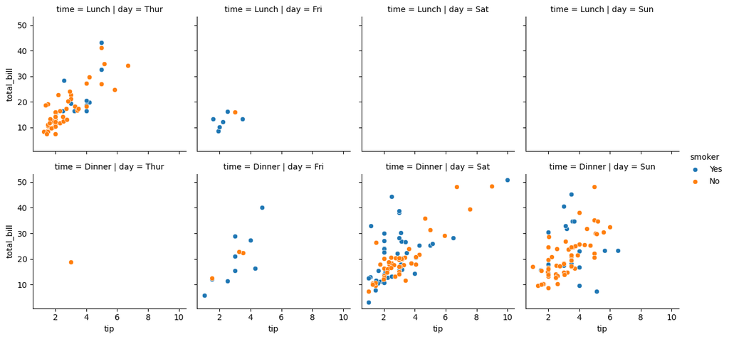

```python
g =sns.FacetGrid(data=tips,col='day',row='time',hue='smoker')
g.map(sns.scatterplot,'tip','total_bill' )
g.add_legend()
```

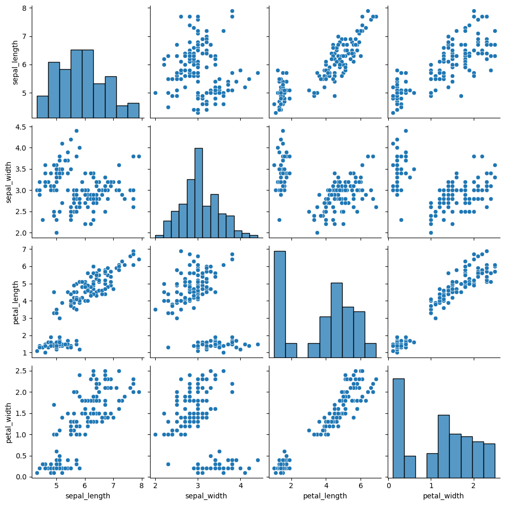

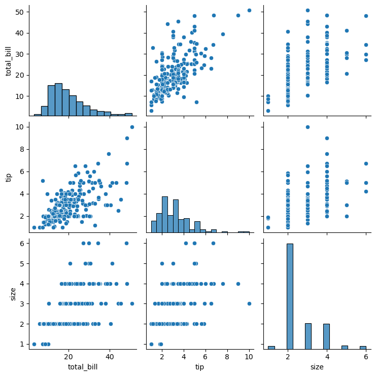

```python
# pair-plot
# detect numerical columns in your data
# add makes pair plot for each pair with each other
# pair plot it puts like scatter for each pair and if same name is occur then it will put histogram
# ()
iris
sns.pairplot(iris)
sns.pairplot(tips)
```

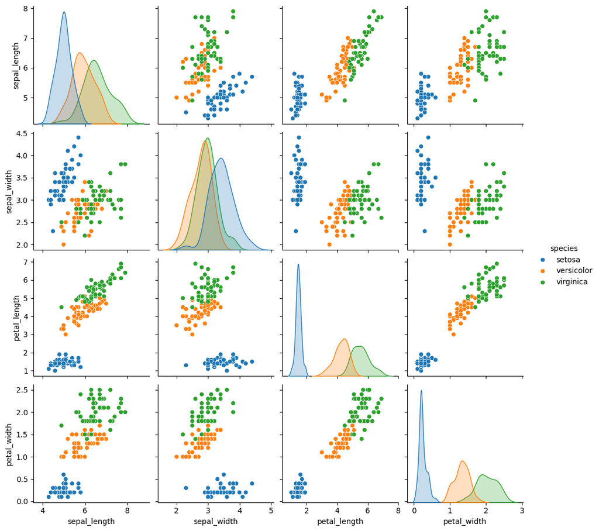

```python
sns.pairplot(iris,hue='species')
```

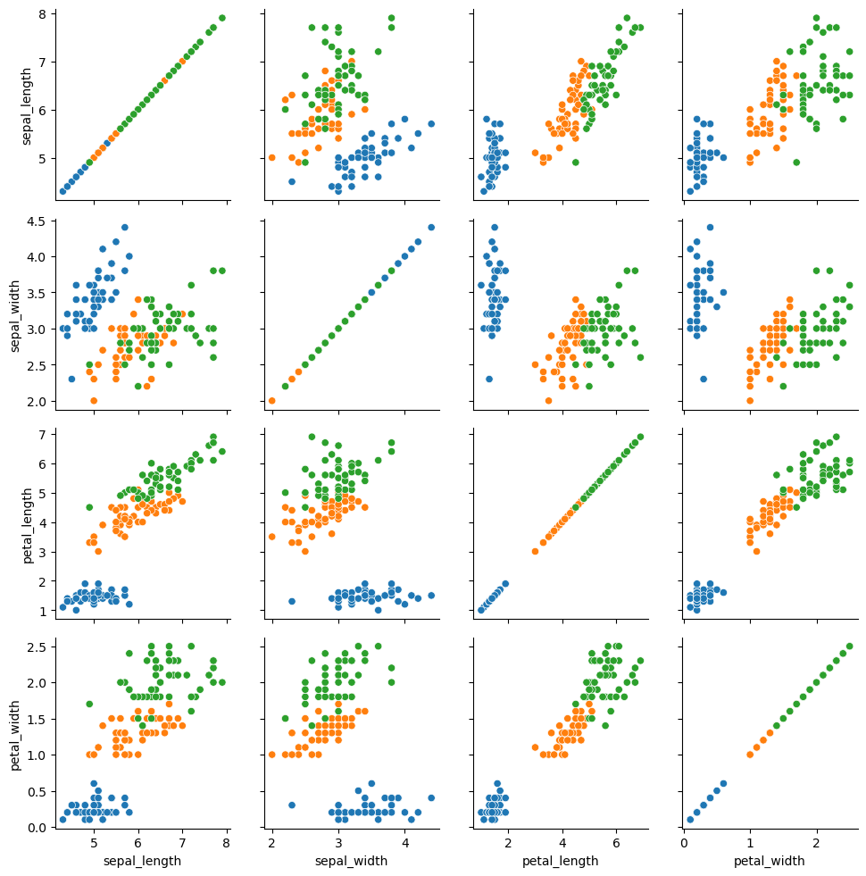

```python
# pairplot is a chold of pairgrid
# in pairgrid we get more options for customization

g = sns.PairGrid(data=iris,hue='species')
g.map(sns.scatterplot)
```

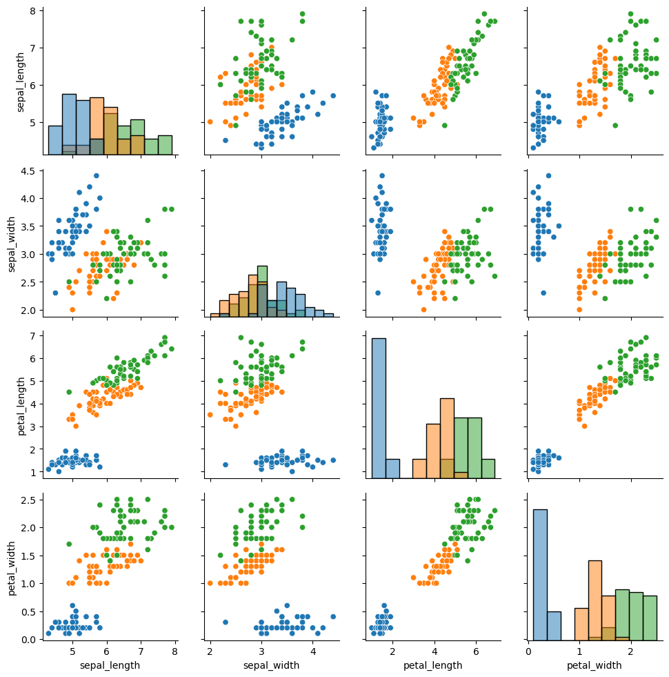

```python
g = sns.PairGrid(data=iris,hue='species')
g.map_diag(sns.histplot)
g.map_offdiag(sns.scatterplot)
# we can plot any type of plot at diagonal and non-diagonal side
```